# Виды анализа данных

Александр Андреев

2024-12-08

# Виды анализа данных

## Прогностический анализ

Прогностический анализ нацелен на предсказание будущих событий и тенденций.

**Пример:** Совершенствование возможностей оценки сердечно-сосудистого риска при помощи методов машинного обучения.

В данном исследовании используются базы медицинских данных для прогнозирования и определения клинических событий кардиологического профиля при помощи методов машинного обучения.

**Ссылка:** [Ссылка на статью](https://cyberleninka.ru/article/n/sovershenstvovanie-vozmozhnostey-otsenki-serdechno-sosudistogo-riska-pri-pomoschi-metodov-mashinnogo-obucheniya)

Таблица как итоговый аналитический результат оценки статьи с сылками на источники данны:

### Перспективы МО в повышении эффективности выявления пациентов высокого риска и предсказания различных событий, связанных с ССЗ:

[output not shown]

## Причинно-следственный анализ

Причинно-следственный анализ фокусируется на выявлении причинно-следственных связей между данными.

**Пример:** Особенности влияния изменения климатических условий на урожайность зерновых культур в сухостепной зоне России.

В рамках исследования проводится анализ влияния изменений погоды на урожайность зерновых культур в сухостепной зоне Оренбургской области РФ.

**Ссылка:** [Ссылка на статью](https://cyberleninka.ru/article/n/osobennosti-vliyaniya-izmeneniya-klimaticheskih-usloviy-na-urozhaynost-zernovyh-kultur-v-suhostepnoy-zone-rossii) Итоговая таблица результатов.

Цитата из статьи и рисунок к результату по цитате:

> Для исследования временных рядов и прогноза урожайности в рамках настоящего исследования выбраны 4 посевные зоны Оренбургской области: $\delta_{1,i}$ – Бузулукский район; $\delta_{2,i}$ – Соль-Илецкий район; $\delta_{3,i}$ – Чебеньки; $\delta_{4,i}$ – Тоцкое. Произведен предварительный анализ временных рядов урожайности при фиксации каждой фиктивной переменной, отвечающей за принадлежность посевной зоне, полученные результаты имеют схожие закономерности, поэтому произведɺм демонстрацию алгоритма только для фиксированной фиктивной переменной (Бузулкский район). С помощью статистических тестов нами доказана нестационарность временного ряда, а также наличие тренда и сезонных компонент.Для того, чтобы отделить накладывающиеся друг на друга сезонные колебания, а также определить периоды смены поведения линии тренда, проведɺм сингулярный спектральный анализ временного ряда. Изображения разложения траекторной матрицы на собственные сингулярные тройки представлено на рисунке 1 (собственные вектора $U_{i,L-1}$ - $U_{i,L-6}$).

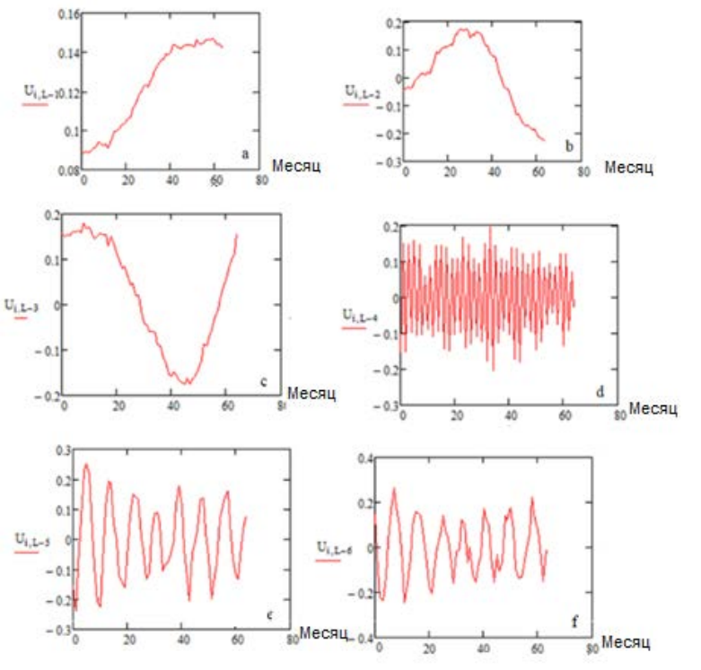

Рисунок 1. Элементарные восстановленные компоненты ряда

Таблица как заключение статьи с результатами оценивания модели.

### Результаты оценивания модели регрессии с фиксированными эффектами для урожайности :

| Коэффициент | Оценка.параметра | Стандартное.отклонение | p.значение |
| --- | --- | --- | --- |
| $\beta_1$ | 0.0080 | 0.009 | 0.1000 |
| $\beta_2$ | 0.9700 | 0.840 | 0.5400 |
| $\gamma$ | 0.8700 | 0.760 | 0.5700 |
| $\delta_1$ | 0.0020 | 0.002 | 0.0001 |
| $\delta_2$ | 0.1530 | 0.051 | 0.0009 |
| $\delta_3$ | 0.0170 | 0.021 | 0.0006 |
| $\delta_4$ | -0.1050 | 0.012 | 0.0003 |
| $\delta_5$ | 0.0500 | 0.013 | 0.0010 |
| $\delta_6$ | 8.3420 | 1.814 | 0.0000 |
| $\delta_7$ | -16.2410 | 3.845 | 0.0000 |
| $\upsilon_1$ | 0.3510 | 0.065 | 0.0004 |
| $\upsilon_2$ | -0.0025 | 0.012 | 0.0004 |
| $\upsilon_3$ | 0.3254 | 0.035 | 0.0010 |
| $\upsilon_4$ | -0.8553 | 0.054 | 0.0008 |